# Airbnb Problem Definition

## Context

Airbnb is an online platform that allows people to rent short-term accommodation. This ranges from regular people with a spare bedroom to property management firms who lease multiple rentals. On the one side, Airbnb enables owners to list their space and earn rental money. On the other side, it provides travellers easy access to renting private homes. Airbnb receives commissions from two sources upon every booking, namely from the hosts and guests. For every booking, Airbnb charges the guest 6-12% of the booking fee. Moreover, Airbnb charges the host 3% for every successful transaction. As a senior data scientist at Airbnb, you have to come up with a pricing model that can effectively predict the Rent for accommodation and can help hosts, travellers, and also the business in devising profitable strategies.

## Objective

To explore and visualize the data, build a linear regression model to predict the prices of Airbnb rental rooms, and generate a set of insights and recommendations that will help the business.

## Data Description

The data contains information about the different types of rental rooms offered by Airbnb over a fixed period of time. The detailed data dictionary is given below.

## Data Dictionary

- id: Property ID
- room_type: Type of Room in the property
- accommodates: How many adults can this property accommodate
- bathrooms: Number of bathrooms on the property
- cancellation_policy: Cancellation policy of the property
- cleaning_fee: This denotes whether the property cleaning fee is included in the rent or not
- instant_bookable: It indicates whether an instant booking facility is available or not
- review_scores_rating: Review rating score of the property
- bedrooms: Number of bedrooms in the property
- beds: Total number of beds in the property
- log_price: Log of the rental price of the property for a fixed period. [If the price is 12000 dollars, then log_price represents log(12000)]

# 1. Load Libraries

```python
# Libraries to help with reading and manipulating data
import numpy as np
import pandas as pd

# Library to suppress warnings or deprecation notes
import warnings

warnings.filterwarnings("ignore")

# Libraries to help with reading and manipulating data

import pandas as pd
import numpy as np

# Library to split data
from sklearn.model_selection import train_test_split

# libaries to help with data visualization
import matplotlib.pyplot as plt
import seaborn as sns

# Removes the limit for the number of displayed columns
pd.set_option("display.max_columns", None)
# Sets the limit for the number of displayed rows
pd.set_option("display.max_rows", 200)

# to split the data into train and test
from sklearn.model_selection import train_test_split

# to build linear regression_model
from sklearn.linear_model import LinearRegression

# to check model performance
from sklearn.metrics import mean_absolute_error, mean_squared_error, r2_score

from sklearn.feature_selection import VarianceThreshold

# to suppress warnings
import warnings

warnings.filterwarnings("ignore")
```

```python
!pip install mlxtend
import joblib
import sys
sys.modules['sklearn.externals.joblib'] = joblib
from mlxtend.feature_selection import SequentialFeatureSelector as SFS
```

# 2. Load data from csv into Pandas dataframe

```python
AirBnBdf = pd.read_csv("/content/drive/MyDrive/Colab Notebooks/Dataset/AirBNB.csv")
```

# 3. Perform Initial analysis of the data

```python
# checking shape of the data
print(f"There are {AirBnBdf.shape[0]} rows and {AirBnBdf.shape[1]} columns.")
```

```
There are 74111 rows and 11 columns.
```

```python
# let's view a sample of the data
# Use random_state=1 to see the same set of results everytime you run this code.
AirBnBdf.sample(n=10, random_state=1)
```

|  | id | room_type | accommodates | bathrooms | cancellation_policy | cleaning_fee | instant_bookable | review_scores_rating | bedrooms | beds | log_price |
| --- | --- | --- | --- | --- | --- | --- | --- | --- | --- | --- | --- |
| 56850 | 13586614 | Entire home/apt | 5.0 | 2.0 | strict | False | f | 100.0 | 2.0 | 3.0 | 7.408531 |
| 68140 | 18222981 | Private room | 3.0 | 1.0 | strict | True | f | 95.0 | 1.0 | 2.0 | 4.605170 |
| 23189 | 13915528 | Entire home/apt | 2.0 | 1.0 | strict | True | f | 95.0 | 1.0 | 2.0 | 4.094345 |
| 47255 | 7122067 | Private room | 1.0 | 1.0 | flexible | False | f | 100.0 | 1.0 | 1.0 | 4.317488 |
| 45933 | 12384924 | Entire home/apt | 5.0 | 2.0 | strict | True | f | 95.0 | 2.0 | 3.0 | 5.433722 |
| 66955 | 3999628 | Private room | 2.0 | 1.0 | moderate | True | f | 98.0 | 1.0 | 1.0 | 5.010635 |
| 18553 | 4948442 | Entire home/apt | 1.0 | 1.0 | strict | False | f | NaN | 0.0 | 1.0 | 5.010635 |
| 26117 | 666837 | Shared room | 16.0 | 2.0 | flexible | False | f | 76.0 | 1.0 | 1.0 | 2.708050 |
| 65737 | 15929932 | Entire home/apt | 10.0 | 1.0 | strict | False | f | 93.0 | 2.0 | 2.0 | 4.976734 |
| 8915 | 21173263 | Entire home/apt | 3.0 | 1.0 | strict | True | f | 95.0 | 0.0 | 2.0 | 4.700480 |

**Observations**

- *id* column is just an index column, as this does not have any value to our model, so we can drop this column.
- *room_type, accommodates, bathrooms, cleaning_fee, cancellation_policy,instant_bookable,bedrooms,beds* seem to have finite set of values, probably they can be considered as categorical values. Let us find out the disctinct values in these columns and decide based on that.
- *review_scores_rating* seem to have a range of values, let us find out the min and max range for this column.
- *log_price* column might need some processing, let us do some processing and see what the actual price looks like.

```python
# let's create a copy of the data to avoid any changes to original data
AirBnBdf_original = AirBnBdf.copy()
```

```python
# drop the id column as it does not add any value to the analysis
AirBnBdf.drop("id", axis=1, inplace=True)
```

```python
# checking column datatypes and number of non-null values
AirBnBdf.info()
```

```
<class 'pandas.core.frame.DataFrame'>
RangeIndex: 74111 entries, 0 to 74110
Data columns (total 10 columns):
 #   Column                Non-Null Count  Dtype
---  ------                --------------  -----
 0   room_type             74106 non-null  object
 1   accommodates          74108 non-null  float64
 2   bathrooms             73908 non-null  float64
 3   cancellation_policy   74103 non-null  object
 4   cleaning_fee          74107 non-null  object
 5   instant_bookable      74111 non-null  object
 6   review_scores_rating  57389 non-null  float64
 7   bedrooms              74019 non-null  float64
 8   beds                  73980 non-null  float64
 9   log_price             74111 non-null  float64
dtypes: float64(6), object(4)
memory usage: 5.7+ MB
```

**Observations**

- The column data types seem to be aligned with the values in the columns.
- Except log_price and instant_bookable columns the rest of the columns have missing values.

#### Do inverse log transformation on log_price column

```python
# Do inverse log on the log_price column and
AirBnBdf.insert(9,"Price",np.exp(AirBnBdf["log_price"]))
AirBnBdf.sample(n=10, random_state=1)
```

|  | room_type | accommodates | bathrooms | cancellation_policy | cleaning_fee | instant_bookable | review_scores_rating | bedrooms | beds | Price | log_price |
| --- | --- | --- | --- | --- | --- | --- | --- | --- | --- | --- | --- |
| 56850 | Entire home/apt | 5.0 | 2.0 | strict | False | f | 100.0 | 2.0 | 3.0 | 1650.0 | 7.408531 |
| 68140 | Private room | 3.0 | 1.0 | strict | True | f | 95.0 | 1.0 | 2.0 | 100.0 | 4.605170 |
| 23189 | Entire home/apt | 2.0 | 1.0 | strict | True | f | 95.0 | 1.0 | 2.0 | 60.0 | 4.094345 |
| 47255 | Private room | 1.0 | 1.0 | flexible | False | f | 100.0 | 1.0 | 1.0 | 75.0 | 4.317488 |
| 45933 | Entire home/apt | 5.0 | 2.0 | strict | True | f | 95.0 | 2.0 | 3.0 | 229.0 | 5.433722 |
| 66955 | Private room | 2.0 | 1.0 | moderate | True | f | 98.0 | 1.0 | 1.0 | 150.0 | 5.010635 |
| 18553 | Entire home/apt | 1.0 | 1.0 | strict | False | f | NaN | 0.0 | 1.0 | 150.0 | 5.010635 |
| 26117 | Shared room | 16.0 | 2.0 | flexible | False | f | 76.0 | 1.0 | 1.0 | 15.0 | 2.708050 |
| 65737 | Entire home/apt | 10.0 | 1.0 | strict | False | f | 93.0 | 2.0 | 2.0 | 145.0 | 4.976734 |
| 8915 | Entire home/apt | 3.0 | 1.0 | strict | True | f | 95.0 | 0.0 | 2.0 | 110.0 | 4.700480 |

### Check for duplicates

The number of duplicates are same irrespective of the inverse log transformation. Let us check the data and see if missing values are causing duplicates

```python
# checking for duplicate rows
AirBnBdf.duplicated().sum()
```

```
19994
```

There are 19994 records in AirBnB dataframe that are duplicated, let us process the fields and do some missing value treatment to see if the number of duplicates get reduced.

# 4. Data Preprocessing

### Get the statistical summary of the columns

```python
# Let's look at the statistical summary of the data
AirBnBdf.describe(include='all').T
```

|  | count | unique | top | freq | mean | std | min | 25% | 50% | 75% | max |
| --- | --- | --- | --- | --- | --- | --- | --- | --- | --- | --- | --- |
| room_type | 74106 | 3 | Entire home/apt | 41308 | NaN | NaN | NaN | NaN | NaN | NaN | NaN |
| accommodates | 74108 | NaN | NaN | NaN | 3.15512 | 2.1536 | 1 | 2 | 2 | 4 | 16 |
| bathrooms | 73908 | NaN | NaN | NaN | 1.23527 | 0.582054 | 0 | 1 | 1 | 1 | 8 |
| cancellation_policy | 74103 | 3 | strict | 32500 | NaN | NaN | NaN | NaN | NaN | NaN | NaN |
| cleaning_fee | 74107 | 2 | True | 54399 | NaN | NaN | NaN | NaN | NaN | NaN | NaN |
| instant_bookable | 74111 | 2 | f | 54660 | NaN | NaN | NaN | NaN | NaN | NaN | NaN |
| review_scores_rating | 57389 | NaN | NaN | NaN | 94.0674 | 7.83656 | 20 | 92 | 96 | 100 | 100 |
| bedrooms | 74019 | NaN | NaN | NaN | 1.2658 | 0.852149 | 0 | 1 | 1 | 1 | 10 |
| beds | 73980 | NaN | NaN | NaN | 1.71087 | 1.25414 | 0 | 1 | 1 | 2 | 18 |
| Price | 74111 | NaN | NaN | NaN | 160.371 | 168.58 | 1 | 75 | 111 | 185 | 1999 |
| log_price | 74111 | NaN | NaN | NaN | 4.78207 | 0.717394 | 0 | 4.31749 | 4.70953 | 5.22036 | 7.6004 |

**Observations**

  *Let us do some data preprocessing by treating the missing values*

## Missing value treatment

```python
AirBnBdf.isnull().sum().sort_values(ascending=False)
```

```
review_scores_rating    16722
bathrooms                 203
beds                      131
bedrooms                   92
cancellation_policy         8
room_type                   5
cleaning_fee                4
accommodates                3
log_price                   0
Price                       0
instant_bookable            0
dtype: int64
```

**Observations**

- The review_scores_rating column has the most number of missing values.
- Let us begin with the column that has least number of missing values

### Process accommodates column

```python
AirBnBdf[AirBnBdf.filter(like='accommodates').isnull().any(1)]
```

|  | room_type | accommodates | bathrooms | cancellation_policy | cleaning_fee | instant_bookable | review_scores_rating | bedrooms | beds | Price | log_price |
| --- | --- | --- | --- | --- | --- | --- | --- | --- | --- | --- | --- |
| 348 | Entire home/apt | NaN | NaN | NaN | False | f | NaN | 0.0 | 1.0 | 100.0 | 4.605170 |
| 349 | Private room | NaN | NaN | NaN | True | f | NaN | 1.0 | 1.0 | 185.0 | 5.220356 |
| 454 | Entire home/apt | NaN | NaN | NaN | True | f | 82.0 | 1.0 | 3.0 | 130.0 | 4.867534 |

- *From the above result we see the NaN values in accomodations is of type Entire home/apt and Private room.*
- *The corresponding bathrooms and cancellation policy values are also NaN.*
- *Let us do a group by on these values and see what will be the best value to replace the missing value.*

```python
AirBnBdf.groupby(['room_type'])['accommodates'].median()
```

```
room_type
Entire home/apt    4.0
Private room       2.0
Shared room        1.0
Name: accommodates, dtype: float64
```

From the above result we see the median value of accomodation for Entire home/apt is 4 and Private room is 2. So replace the missing values with this median.

```python
# replace missing values with median values, for Entire room/apt the median value is 4
AirBnBdf.loc[(AirBnBdf.room_type == 'Entire home/apt') & (AirBnBdf.accommodates.isnull()),['accommodates']] = 4
AirBnBdf[(AirBnBdf.room_type == 'Entire home/apt') & (AirBnBdf.accommodates.isnull())]
```

|  | room_type | accommodates | bathrooms | cancellation_policy | cleaning_fee | instant_bookable | review_scores_rating | bedrooms | beds | Price | log_price |
| --- | --- | --- | --- | --- | --- | --- | --- | --- | --- | --- | --- |

```python
# replace missing values with median values, for Private room the median value is 2
AirBnBdf.loc[(AirBnBdf.room_type == 'Private room') & (AirBnBdf.accommodates.isnull()),['accommodates']] = 2
AirBnBdf[(AirBnBdf.room_type == 'Private room') & (AirBnBdf.accommodates.isnull())]
```

|  | room_type | accommodates | bathrooms | cancellation_policy | cleaning_fee | instant_bookable | review_scores_rating | bedrooms | beds | Price | log_price |
| --- | --- | --- | --- | --- | --- | --- | --- | --- | --- | --- | --- |

### Process room_type column

```python
AirBnBdf.groupby(['room_type']).agg(['mean', 'count', 'sum'])
```

| room_type | accommodates mean | accommodates count | accommodates sum | bathrooms mean | bathrooms count | bathrooms sum | review_scores_rating mean | review_scores_rating count | review_scores_rating sum | bedrooms mean | bedrooms count | bedrooms sum | beds mean | beds count | beds sum | Price mean | Price count | Price sum | log_price mean | log_price count | log_price sum |
| --- | --- | --- | --- | --- | --- | --- | --- | --- | --- | --- | --- | --- | --- | --- | --- | --- | --- | --- | --- | --- | --- |
| Entire home/apt | 4.078677 | 41308 | 168482.0 | 1.307802 | 41244 | 53939.0 | 94.303044 | 33015 | 3113415.0 | 1.458375 | 41237 | 60139.0 | 2.107878 | 41278 | 87009.0 | 218.748378 | 41308 | 9.036058e+06 | 5.167225 | 41308 | 213447.737816 |
| Private room | 1.988379 | 30635 | 60914.0 | 1.129806 | 30507 | 34467.0 | 93.865704 | 22927 | 2152059.0 | 1.025185 | 30614 | 31385.0 | 1.172254 | 30548 | 35810.0 | 88.484446 | 30635 | 2.710721e+06 | 4.327734 | 30635 | 132580.125960 |
| Shared room | 2.043920 | 2163 | 4421.0 | 1.340149 | 2152 | 2884.0 | 91.871795 | 1443 | 132571.0 | 1.000000 | 2163 | 2163.0 | 1.741740 | 2149 | 3743.0 | 63.681923 | 2163 | 1.377440e+05 | 3.861535 | 2163 | 8352.499673 |

```python
AirBnBdf[AirBnBdf.filter(like='room_type').isnull().any(1)]
```

|  | room_type | accommodates | bathrooms | cancellation_policy | cleaning_fee | instant_bookable | review_scores_rating | bedrooms | beds | Price | log_price |
| --- | --- | --- | --- | --- | --- | --- | --- | --- | --- | --- | --- |
| 141 | NaN | 1.0 | 1.0 | flexible | False | f | NaN | 1.0 | 1.0 | 250.0 | 5.521461 |
| 167 | NaN | 5.0 | 1.0 | strict | True | f | 97.0 | 2.0 | 3.0 | 264.0 | 5.575949 |
| 195 | NaN | 2.0 | 1.0 | moderate | True | f | 99.0 | 1.0 | 1.0 | 35.0 | 3.555348 |
| 255 | NaN | 4.0 | 1.0 | moderate | True | f | 91.0 | 1.0 | 2.0 | 83.0 | 4.418841 |
| 552 | NaN | 1.0 | 2.5 | strict | True | t | 100.0 | 1.0 | 1.0 | 89.0 | 4.488636 |

**Observation:**

Accomodation size and roomtypes are directly proportional to each other, from the above group by query it is clear that:

- If the rental property can accomodate 4 or more people then it shouold be an 'Entire home/apt'.
- If the rental property of a private room can accomodate 2 people.
- If the property can accomodate 1 person then mostly it is a shared room.

*We can update the room types based on this data.*

```python
AirBnBdf.groupby(['room_type'])['accommodates'].median()
```

```
room_type
Entire home/apt    4.0
Private room       2.0
Shared room        1.0
Name: accommodates, dtype: float64
```

From the above result we see the median value of accomodation for Entire home/apt is 4 and Private room is 2. So replace the missing values with this median.

```python
# replace missing values of room type as Entire home/apt if the rental property can accomodate 4 or more people
AirBnBdf.loc[(AirBnBdf.room_type.isnull() & (AirBnBdf.accommodates >= 4)),['room_type']] = 'Entire home/apt'
AirBnBdf[(AirBnBdf.accommodates >= 4) & (AirBnBdf.room_type.isnull())]
```

|  | room_type | accommodates | bathrooms | cancellation_policy | cleaning_fee | instant_bookable | review_scores_rating | bedrooms | beds | Price | log_price |
| --- | --- | --- | --- | --- | --- | --- | --- | --- | --- | --- | --- |

```python
# replace missing values of room type as Private room if the rental property can accomodate between 2 to 3 persons
AirBnBdf.loc[(AirBnBdf.room_type.isnull() & (AirBnBdf.accommodates == 2) | (AirBnBdf.accommodates == 3 )),['room_type']] = 'Private room'
AirBnBdf[(AirBnBdf.accommodates >= 2) & (AirBnBdf.room_type.isnull())]
```

|  | room_type | accommodates | bathrooms | cancellation_policy | cleaning_fee | instant_bookable | review_scores_rating | bedrooms | beds | Price | log_price |
| --- | --- | --- | --- | --- | --- | --- | --- | --- | --- | --- | --- |

```python
# if the room accomodates only one person then it is a Private room
AirBnBdf.loc[(AirBnBdf.room_type.isnull() & (AirBnBdf.accommodates == 1)),['room_type']] = 'Private room'
AirBnBdf[(AirBnBdf.accommodates == 1) & (AirBnBdf.room_type.isnull())]
```

|  | room_type | accommodates | bathrooms | cancellation_policy | cleaning_fee | instant_bookable | review_scores_rating | bedrooms | beds | Price | log_price |
| --- | --- | --- | --- | --- | --- | --- | --- | --- | --- | --- | --- |

### Process cleaning_fee and cancellation_policy column

```python
# since, majority of rental properties have cleaning fee and majority of properties have strict cancellation
# we can assign these values for the missing values
AirBnBdf.loc[(AirBnBdf.cancellation_policy.isnull()),['cancellation_policy']] = 'strict'
AirBnBdf[(AirBnBdf.cancellation_policy.isnull())]
```

|  | room_type | accommodates | bathrooms | cancellation_policy | cleaning_fee | instant_bookable | review_scores_rating | bedrooms | beds | Price | log_price |
| --- | --- | --- | --- | --- | --- | --- | --- | --- | --- | --- | --- |

```python
# since, majority of rental properties have cleaning fee and majority of properties have strict cancellation
# we can assign these values for the missing values
AirBnBdf.loc[(AirBnBdf.cleaning_fee.isnull()),['cleaning_fee']] = True
AirBnBdf[(AirBnBdf.cleaning_fee.isnull())]
```

|  | room_type | accommodates | bathrooms | cancellation_policy | cleaning_fee | instant_bookable | review_scores_rating | bedrooms | beds | Price | log_price |
| --- | --- | --- | --- | --- | --- | --- | --- | --- | --- | --- | --- |

### Process bedrooms column

```python
AirBnBdf.groupby(['accommodates'])['bedrooms'].median()
```

```
accommodates
1.0     1.0
2.0     1.0
3.0     1.0
4.0     1.0
5.0     2.0
6.0     2.0
7.0     3.0
8.0     3.0
9.0     3.0
10.0    4.0
11.0    4.0
12.0    4.0
13.0    4.0
14.0    5.0
15.0    4.0
16.0    4.0
Name: bedrooms, dtype: float64
```

- Based on the above result, single bedroom rentals can accomodate upto 4 people.
- Rentals having 2 to 3 bedrooms can accomodate upto 9 people
- For accomodating 10 people or more the rentals have 4 or more bedrooms.
- Taking this into consideration, we can set the missing bedroom counts accordingly.

```python
AirBnBdf.loc[((AirBnBdf.bedrooms.isnull()) | (AirBnBdf.bedrooms == 0)) & (AirBnBdf.accommodates <= 4) ,['bedrooms']] = 1
AirBnBdf.loc[((AirBnBdf.bedrooms.isnull()) | (AirBnBdf.bedrooms == 0)) & (AirBnBdf.accommodates <= 9) ,['bedrooms']] = 3
AirBnBdf.loc[((AirBnBdf.bedrooms.isnull()) | (AirBnBdf.bedrooms == 0)) & (AirBnBdf.accommodates >= 10) ,['bedrooms']] = 4
AirBnBdf[(AirBnBdf.bedrooms.isnull() | (AirBnBdf.bedrooms == 0))]
```

|  | room_type | accommodates | bathrooms | cancellation_policy | cleaning_fee | instant_bookable | review_scores_rating | bedrooms | beds | Price | log_price |
| --- | --- | --- | --- | --- | --- | --- | --- | --- | --- | --- | --- |

### Process bathrooms column

```python
AirBnBdf.groupby(['accommodates'])['bathrooms'].median()
```

```
accommodates
1.0     1.0
2.0     1.0
3.0     1.0
4.0     1.0
5.0     1.0
6.0     1.5
7.0     2.0
8.0     2.0
9.0     2.0
10.0    2.0
11.0    2.0
12.0    2.5
13.0    2.0
14.0    3.0
15.0    2.0
16.0    2.5
Name: bathrooms, dtype: float64
```

- By looking at the above result let us consider 2 bathrooms for accomodations between 6 and 11.
- For accomodations more than 11, consider 3 bathrooms.

```python
AirBnBdf.loc[((AirBnBdf.bathrooms.isnull()) | (AirBnBdf.bathrooms == 0)) & ((AirBnBdf.accommodates >= 1) & (AirBnBdf.accommodates <= 5)) ,['bathrooms']] = 1
AirBnBdf.loc[((AirBnBdf.bathrooms.isnull()) | (AirBnBdf.bathrooms == 0)) & ((AirBnBdf.accommodates >= 6) & (AirBnBdf.accommodates <= 11)) ,['bathrooms']] = 2
AirBnBdf.loc[((AirBnBdf.bathrooms.isnull()) | (AirBnBdf.bathrooms == 0)) & (AirBnBdf.accommodates >= 12) ,['bathrooms']] = 3
AirBnBdf[(AirBnBdf.bathrooms.isnull() | (AirBnBdf.bathrooms == 0))]
```

|  | room_type | accommodates | bathrooms | cancellation_policy | cleaning_fee | instant_bookable | review_scores_rating | bedrooms | beds | Price | log_price |
| --- | --- | --- | --- | --- | --- | --- | --- | --- | --- | --- | --- |

### Process beds column

```python
AirBnBdf.groupby(['accommodates'])['beds'].median()
```

```
accommodates
1.0     1.0
2.0     1.0
3.0     1.0
4.0     2.0
5.0     3.0
6.0     3.0
7.0     4.0
8.0     4.0
9.0     5.0
10.0    5.0
11.0    6.0
12.0    6.0
13.0    7.0
14.0    7.0
15.0    7.5
16.0    7.0
Name: beds, dtype: float64
```

- Single bed can accomodate upto 3 people
- 2 beds for 4 people
- Between 5 and 6 people 3 beds are needed
- Between 7 and 8 people 4 beds are needed,
- 9 and 10 people = 5 beds
- 11 and 12 people = 6 beds
- To accomodate 13 and above 7 beds are required

```python
AirBnBdf.loc[((AirBnBdf.beds.isnull()) | (AirBnBdf.beds == 0)) & ((AirBnBdf.accommodates >= 5) & (AirBnBdf.accommodates <= 6)) ,['beds']] = 3
AirBnBdf.loc[((AirBnBdf.beds.isnull()) | (AirBnBdf.beds == 0)) & ((AirBnBdf.accommodates >= 7) & (AirBnBdf.accommodates <= 8)) ,['beds']] = 4
AirBnBdf.loc[((AirBnBdf.beds.isnull()) | (AirBnBdf.beds == 0)) & ((AirBnBdf.accommodates >= 9) & (AirBnBdf.accommodates <= 10)) ,['beds']] = 5
AirBnBdf.loc[((AirBnBdf.beds.isnull()) | (AirBnBdf.beds == 0)) & ((AirBnBdf.accommodates >= 11) & (AirBnBdf.accommodates <= 12)) ,['beds']] = 6
AirBnBdf.loc[((AirBnBdf.beds.isnull()) | (AirBnBdf.beds == 0)) & (AirBnBdf.accommodates <= 3) ,['beds']] = 1
AirBnBdf.loc[((AirBnBdf.beds.isnull()) | (AirBnBdf.beds == 0)) & (AirBnBdf.accommodates == 4) ,['beds']] = 2
AirBnBdf.loc[((AirBnBdf.beds.isnull()) | (AirBnBdf.beds == 0)) & (AirBnBdf.accommodates >= 13) ,['beds']] = 7
AirBnBdf[(AirBnBdf.beds.isnull() | (AirBnBdf.beds == 0))]
```

|  | room_type | accommodates | bathrooms | cancellation_policy | cleaning_fee | instant_bookable | review_scores_rating | bedrooms | beds | Price | log_price |
| --- | --- | --- | --- | --- | --- | --- | --- | --- | --- | --- | --- |

```python
AirBnBdf.duplicated().sum()
```

```
22386
```

We still have lot of duplicates in the data

### Process review_scores column

```python
AirBnBdf_original.loc[(AirBnBdf_original['review_scores_rating'] == 0)]
```

|  | id | room_type | accommodates | bathrooms | cancellation_policy | cleaning_fee | instant_bookable | review_scores_rating | bedrooms | beds | log_price |
| --- | --- | --- | --- | --- | --- | --- | --- | --- | --- | --- | --- |

```python
AirBnBdf.groupby(['room_type'])['review_scores_rating'].agg(['mean', 'count', 'sum'])
```

| room_type | mean | count | sum |
| --- | --- | --- | --- |
| Entire home/apt | 94.319251 | 28357 | 2674611.0 |
| Private room | 93.917956 | 27668 | 2598522.0 |
| Shared room | 91.861437 | 1364 | 125299.0 |

**Observations**

- It looks like the average rating for all the room types is above 90. Which means most of the accomodations have an excellent score.
- This data seems to have lot of outliers.

### Process Price column

- Accomodations charging 1500 dollars and above seem to be an above normal price range, so let us check the accomodations in this price range and do some analysis.

```python
tempdf = AirBnBdf.loc[(AirBnBdf.Price > 1500)]

tempdf.groupby(['room_type']).agg(['mean', 'count', 'sum'])
```

| room_type | accommodates mean | accommodates count | accommodates sum | bathrooms mean | bathrooms count | bathrooms sum | review_scores_rating mean | review_scores_rating count | review_scores_rating sum | bedrooms mean | bedrooms count | bedrooms sum | beds mean | beds count | beds sum | Price mean | Price count | Price sum | log_price mean | log_price count | log_price sum |
| --- | --- | --- | --- | --- | --- | --- | --- | --- | --- | --- | --- | --- | --- | --- | --- | --- | --- | --- | --- | --- | --- |
| Entire home/apt | 8.824176 | 91 | 803.0 | 3.978022 | 91 | 362.0 | 95.62069 | 29 | 2773.0 | 4.065934 | 91 | 370.0 | 5.000000 | 91 | 455.0 | 1785.131868 | 91 | 162447.000005 | 7.484247 | 91 | 681.066453 |
| Private room | 6.000000 | 6 | 36.0 | 1.916667 | 6 | 11.5 | NaN | 0 | 0.0 | 2.166667 | 6 | 13.0 | 1.833333 | 6 | 11.0 | 1765.000000 | 6 | 10589.999999 | 7.473071 | 6 | 44.838425 |

```python
tempdf[(tempdf.room_type == 'Private room')]
```

|  | room_type | accommodates | bathrooms | cancellation_policy | cleaning_fee | instant_bookable | review_scores_rating | bedrooms | beds | Price | log_price |
| --- | --- | --- | --- | --- | --- | --- | --- | --- | --- | --- | --- |
| 9390 | Private room | 2.0 | 1.0 | strict | False | f | NaN | 1.0 | 1.0 | 1994.999999 | 7.598399 |
| 44107 | Private room | 1.0 | 1.0 | flexible | False | f | NaN | 1.0 | 1.0 | 1700.000000 | 7.438384 |
| 64484 | Private room | 16.0 | 2.0 | moderate | True | t | NaN | 4.0 | 1.0 | 1650.000000 | 7.408531 |
| 68731 | Private room | 8.0 | 4.5 | moderate | True | t | NaN | 4.0 | 5.0 | 1850.000000 | 7.522941 |
| 69295 | Private room | 3.0 | 1.0 | flexible | False | f | NaN | 1.0 | 1.0 | 1800.000000 | 7.495542 |
| 73186 | Private room | 6.0 | 2.0 | flexible | False | t | NaN | 2.0 | 2.0 | 1595.000000 | 7.374629 |

- Looking at the above result, private room with 4 bedrooms but only 1 bed to accomodate 16 people does seem to be realistic, so we can go ahead and delete this record.

```python
AirBnBdf = AirBnBdf.drop(index=64484)
# AirBnBdf.reset_index()
```

**Observations:**

- There aren't many accomodations above 1500 dollars, they look like outliers. Let us check this data and see if they are correct.

### Process review_scores_rating column

```python
# AirBnBdf[(AirBnBdf.review_scores_rating.isnull() | AirBnBdf.review_scores_rating == 0) & (AirBnBdf.room_type == 'Private room')]
AirBnBdf[((AirBnBdf.review_scores_rating.isnull()) | (AirBnBdf.review_scores_rating == 0)) & (AirBnBdf.room_type == 'Entire home/apt')]
```

|  | room_type | accommodates | bathrooms | cancellation_policy | cleaning_fee | instant_bookable | review_scores_rating | bedrooms | beds | Price | log_price |
| --- | --- | --- | --- | --- | --- | --- | --- | --- | --- | --- | --- |
| 3 | Entire home/apt | 4.0 | 1.0 | flexible | True | f | NaN | 2.0 | 2.0 | 750.0 | 6.620073 |
| 24 | Entire home/apt | 4.0 | 1.0 | moderate | True | f | NaN | 1.0 | 2.0 | 1050.0 | 6.956545 |
| 34 | Entire home/apt | 4.0 | 1.0 | flexible | True | t | NaN | 1.0 | 2.0 | 78.0 | 4.356709 |
| 40 | Entire home/apt | 5.0 | 2.0 | strict | True | t | NaN | 2.0 | 2.0 | 250.0 | 5.521461 |
| 45 | Entire home/apt | 2.0 | 1.0 | flexible | False | f | NaN | 1.0 | 1.0 | 250.0 | 5.521461 |
| ... | ... | ... | ... | ... | ... | ... | ... | ... | ... | ... | ... |
| 74071 | Entire home/apt | 4.0 | 1.0 | flexible | False | f | NaN | 1.0 | 1.0 | 189.0 | 5.241747 |
| 74080 | Entire home/apt | 2.0 | 1.0 | flexible | False | f | NaN | 1.0 | 1.0 | 100.0 | 4.605170 |
| 74081 | Entire home/apt | 16.0 | 1.0 | moderate | False | t | NaN | 1.0 | 1.0 | 1000.0 | 6.907755 |
| 74095 | Entire home/apt | 2.0 | 1.0 | flexible | False | f | NaN | 1.0 | 1.0 | 80.0 | 4.382027 |
| 74109 | Entire home/apt | 2.0 | 1.0 | strict | True | t | NaN | 1.0 | 2.0 | 195.0 | 5.273000 |

7145 rows × 11 columns

```python
# AirBnBdf.groupby(['room_type','bathrooms','beds','bedrooms'])['review_scores_rating'].mean()
AirBnBdf['review_scores_rating']=AirBnBdf.groupby(['room_type','accommodates','bathrooms','beds','bedrooms','cancellation_policy','cleaning_fee'])['review_scores_rating'].apply(lambda x:x.fillna(x.median()))
AirBnBdf['review_scores_rating'].isnull().sum()
```

```
932
```

```python
# AirBnBdf.groupby(['room_type','accommodates','bathrooms'])['review_scores_rating'].median()
AirBnBdf['review_scores_rating']=AirBnBdf.groupby(['room_type','accommodates','bathrooms','bedrooms'])['review_scores_rating'].apply(lambda x:x.fillna(x.median()))
AirBnBdf['review_scores_rating'].isnull().sum()
```

```
123
```

```python
AirBnBdf['review_scores_rating']=AirBnBdf.groupby(['room_type','accommodates','bedrooms'])['review_scores_rating'].apply(lambda x:x.fillna(x.median()))
AirBnBdf['review_scores_rating'].isnull().sum()
```

```
31
```

```python
AirBnBdf['review_scores_rating']=AirBnBdf.groupby(['room_type'])['review_scores_rating'].apply(lambda x:x.fillna(x.median()))
AirBnBdf['review_scores_rating'].isnull().sum()
```

```
0
```

### Check missing values again

```python
AirBnBdf.isnull().sum().sort_values(ascending=False)
```

```
log_price               0
Price                   0
beds                    0
bedrooms                0
review_scores_rating    0
instant_bookable        0
cleaning_fee            0
cancellation_policy     0
bathrooms               0
accommodates            0
room_type               0
dtype: int64
```

There are no missing values now, all of them have been treated.

## Binning review_scores_ratings

```python
# can add custom labels
AirBnBdf['ratings_bin'] = pd.cut(
    AirBnBdf['review_scores_rating'], [0, 20, 40 ,60,80,100],
    labels = ["Poor", "Satisfactory", "Good", "Very Good", "Excellent"]
)
# AirBnBdf.drop(['review_scores_rating'], axis=1, inplace=True)
AirBnBdf['ratings_bin'].value_counts(dropna=False)
```

```
Excellent       70159
Very Good        3240
Good              514
Satisfactory       99
Poor               98
Name: ratings_bin, dtype: int64
```

```python
# Convert review ratings into a categorical column, there are lot of missing values to be handled
binned_ratings = pd.cut(AirBnBdf['review_scores_rating'], [0, 20, 40 ,60,80, 100])
binned_ratings
```

```
0        (80, 100]
1        (80, 100]
2        (80, 100]
3        (80, 100]
4         (20, 40]
           ...
74106    (80, 100]
74107    (80, 100]
74108    (80, 100]
74109    (80, 100]
74110    (80, 100]
Name: review_scores_rating, Length: 74110, dtype: category
Categories (5, interval[int64]): [(0, 20] < (20, 40] < (40, 60] < (60, 80] < (80, 100]]
```

```python
binned_ratings.value_counts(dropna=False)
```

```
(80, 100]    70159
(60, 80]      3240
(40, 60]       514
(20, 40]        99
(0, 20]         98
Name: review_scores_rating, dtype: int64
```

```python
# checking for duplicate values
AirBnBdf.duplicated().sum()
```

```
23633
```

## Converting object data types to category data type for categorical columns

```python
categorical_vars = ['cleaning_fee', 'cancellation_policy', 'room_type',
            'instant_bookable']

for colname in categorical_vars:
    AirBnBdf[colname] = AirBnBdf[colname].astype('category')

AirBnBdf.info()
```

```
<class 'pandas.core.frame.DataFrame'>
Int64Index: 74110 entries, 0 to 74110
Data columns (total 12 columns):
 #   Column                Non-Null Count  Dtype
---  ------                --------------  -----
 0   room_type             74110 non-null  category
 1   accommodates          74110 non-null  float64
 2   bathrooms             74110 non-null  float64
 3   cancellation_policy   74110 non-null  category
 4   cleaning_fee          74110 non-null  category
 5   instant_bookable      74110 non-null  category
 6   review_scores_rating  74110 non-null  float64
 7   bedrooms              74110 non-null  float64
 8   beds                  74110 non-null  float64
 9   Price                 74110 non-null  float64
 10  log_price             74110 non-null  float64
 11  ratings_bin           74110 non-null  category
dtypes: category(5), float64(7)
memory usage: 7.4 MB
```

## Check for duplicates and drop duplicates

```python
# checking for duplicate values
AirBnBdf.duplicated().sum()
```

```
23633
```

```python
#drop duplicate records
AirBnBdf = AirBnBdf.drop_duplicates()
AirBnBdf[AirBnBdf.duplicated(keep=False) == True]
AirBnBdf.shape
```

```
(50477, 12)
```

```python
# checking for duplicate values
AirBnBdf.duplicated().sum()
```

```
0
```

There are no duplicates after dropping the duplicate records

```python
AirBnBdf.info()
```

```
<class 'pandas.core.frame.DataFrame'>
Int64Index: 50477 entries, 0 to 74110
Data columns (total 12 columns):
 #   Column                Non-Null Count  Dtype
---  ------                --------------  -----
 0   room_type             50477 non-null  category
 1   accommodates          50477 non-null  float64
 2   bathrooms             50477 non-null  float64
 3   cancellation_policy   50477 non-null  category
 4   cleaning_fee          50477 non-null  category
 5   instant_bookable      50477 non-null  category
 6   review_scores_rating  50477 non-null  float64
 7   bedrooms              50477 non-null  float64
 8   beds                  50477 non-null  float64
 9   Price                 50477 non-null  float64
 10  log_price             50477 non-null  float64
 11  ratings_bin           50477 non-null  category
dtypes: category(5), float64(7)
memory usage: 3.3 MB
```

## Let us check the numeric columns for skewness

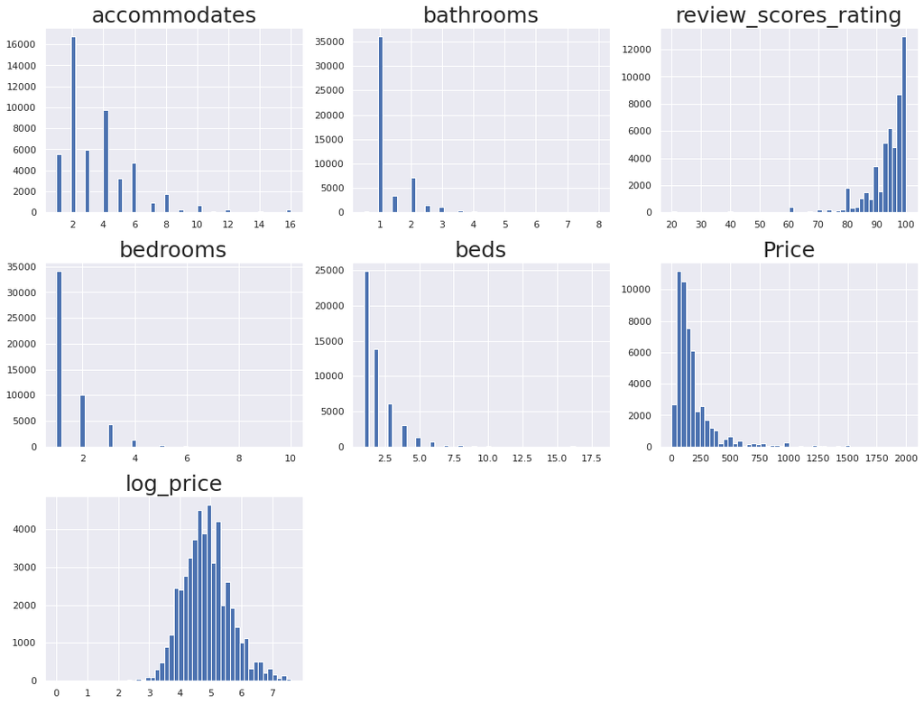

```python
# creating a list of numeric columns
dist_cols = [
    item for item in AirBnBdf.select_dtypes(include=np.number).columns
]

# let's plot a histogram of all numeric columns

plt.figure(figsize=(15, 45))

for i in range(len(dist_cols)):
    plt.subplot(12, 3, i + 1)
    plt.hist(AirBnBdf[dist_cols[i]], bins=50)
    plt.tight_layout()
    plt.title(dist_cols[i], fontsize=25)

plt.show()
```

# 5. Exploratory Data Analysis

## Univariate Analysis

### Functions to create charts

```python
# function to create labeled barplots

def labeled_barplot(data, feature, perc=False, n=None):
    """
    Barplot with percentage at the top

    data: dataframe
    feature: dataframe column
    perc: whether to display percentages instead of count (default is False)
    n: displays the top n category levels (default is None, i.e., display all levels)
    """

    total = len(data[feature])  # length of the column
    count = data[feature].nunique()
    if n is None:
        plt.figure(figsize=(count + 1, 5))
    else:
        plt.figure(figsize=(n + 1, 5))

    plt.xticks(rotation=90, fontsize=15)
    ax = sns.countplot(
        data=data,
        x=feature,
        palette="Paired",
        order=data[feature].value_counts().index[:n].sort_values(),
    )

    for p in ax.patches:
        if perc == True:
            label = "{:.1f}%".format(
                100 * p.get_height() / total
            )  # percentage of each class of the category
        else:
            label = p.get_height()  # count of each level of the category

        x = p.get_x() + p.get_width() / 2  # width of the plot
        y = p.get_height()  # height of the plot

        ax.annotate(
            label,
            (x, y),
            ha="center",
            va="center",
            size=12,
            xytext=(0, 5),
            textcoords="offset points",
        )  # annotate the percentage

    plt.show()  # show the plot
```

```python
# function to plot a boxplot and a histogram along the same scale.


def histogram_boxplot(data, feature, figsize=(12, 7), kde=False, bins=None):
    """
    Boxplot and histogram combined

    data: dataframe
    feature: dataframe column
    figsize: size of figure (default (12,7))
    kde: whether to the show density curve (default False)
    bins: number of bins for histogram (default None)
    """
    f2, (ax_box2, ax_hist2) = plt.subplots(
        nrows=2,  # Number of rows of the subplot grid= 2
        sharex=True,  # x-axis will be shared among all subplots
        gridspec_kw={"height_ratios": (0.25, 0.75)},
        figsize=figsize,
    )  # creating the 2 subplots
    sns.boxplot(
        data=data, x=feature, ax=ax_box2, showmeans=True, color="violet"
    )  # boxplot will be created and a star will indicate the mean value of the column
    sns.histplot(
        data=data, x=feature, kde=kde, ax=ax_hist2, bins=bins, palette="winter"
    ) if bins else sns.histplot(
        data=data, x=feature, kde=kde, ax=ax_hist2
    )  # For histogram
    ax_hist2.axvline(
        data[feature].mean(), color="green", linestyle="--"
    )  # Add mean to the histogram
    ax_hist2.axvline(
        data[feature].median(), color="black", linestyle="-"
    )  # Add median to the histogram
```

### How many rentals are available across different types of properties ?

```python
AirBnBdf.room_type.value_counts()
```

```
Entire home/apt    27055
Private room       21723
Shared room         1699
Name: room_type, dtype: int64
```

### room_type

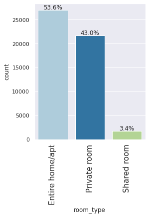

```python
labeled_barplot(AirBnBdf, "room_type", perc=True)
```

**Observations**

### Price

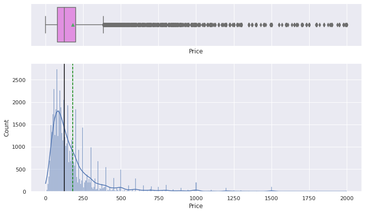

```python
histogram_boxplot(AirBnBdf, "Price", kde=True)
```

### log_price

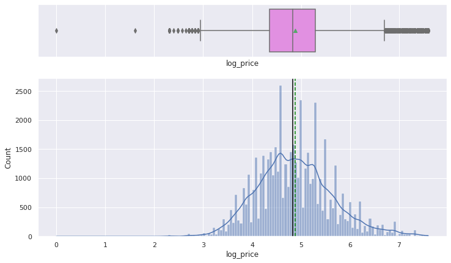

```python
histogram_boxplot(AirBnBdf, "log_price", kde=True)
```

### bedrooms

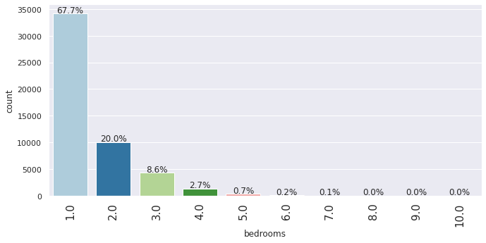

```python
labeled_barplot(AirBnBdf, "bedrooms", perc=True)
```

- About 67.7% of the accomodations have single bedrooms, 20% of them have 2 bedrooms.
- About 20% of them are 2 bedrooms, rest of them are 3 and above.

### bathrooms

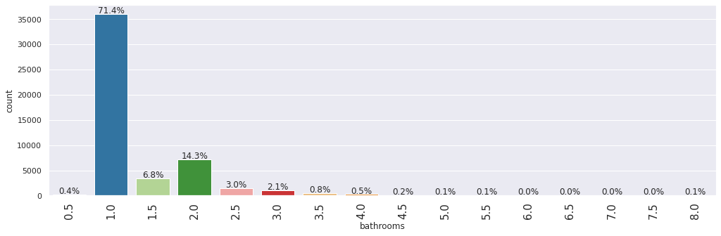

```python
labeled_barplot(AirBnBdf, "bathrooms", perc=True)
```

- About 71.4% of the accomodations have single bathrooms, 14.3% of them have 2 bathrooms, rest of the distributions are very minimal.

### beds

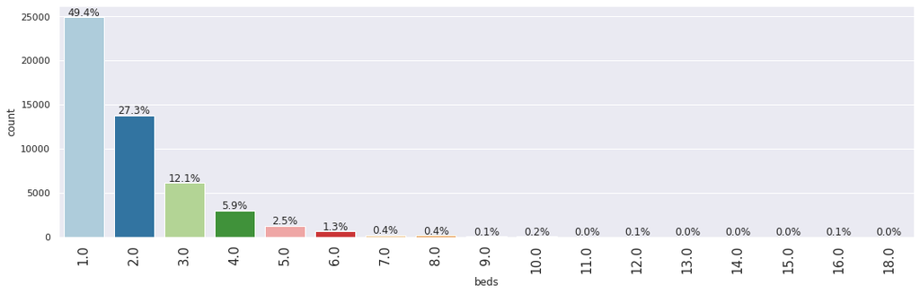

```python
labeled_barplot(AirBnBdf, "beds", perc=True)
```

- beds have a distribution similar to bedrooms and bathrooms.

### ratings_bin

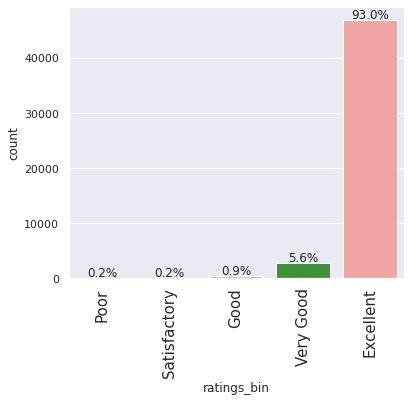

```python
labeled_barplot(AirBnBdf, "ratings_bin", perc=True)
```

- Most of them have Excellent rating score

### cleaning_fee

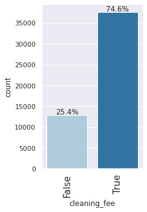

```python
labeled_barplot(AirBnBdf, "cleaning_fee", perc=True)
```

### instant_bookable

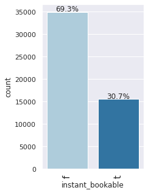

```python
labeled_barplot(AirBnBdf, "instant_bookable", perc=True)
```

- About 30% of the accomodations can be booked instantly, rest of them cannot be.

### cancellation_policy

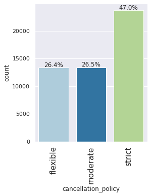

```python
labeled_barplot(AirBnBdf, "cancellation_policy", perc=True)
```

- About 47% of the rentals have a strict cancellation policy, while 26.4% of them are flexible and 26.5% of them are moderate.

### review_scores_rating

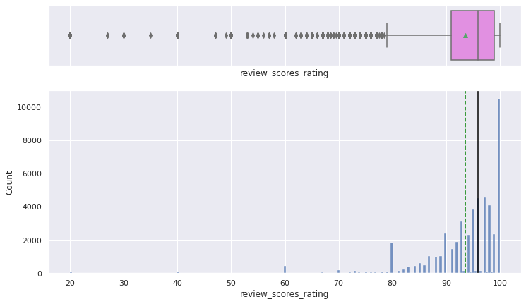

```python
#review_scores_rating
histogram_boxplot(AirBnBdf, "review_scores_rating")
```

## Outlier Treatment

#### Treat outliers in review_scores_rating column

```python
AirBnBdf.insert(5,"review_score_log",np.log(AirBnBdf["review_scores_rating"]))
AirBnBdf.sample(n=10, random_state=1)
```

|  | room_type | accommodates | bathrooms | cancellation_policy | cleaning_fee | review_score_log | instant_bookable | review_scores_rating | bedrooms | beds | Price | log_price | ratings_bin |
| --- | --- | --- | --- | --- | --- | --- | --- | --- | --- | --- | --- | --- | --- |
| 9802 | Entire home/apt | 4.0 | 1.5 | strict | True | 4.574711 | f | 97.0 | 2.0 | 2.0 | 250.0 | 5.521461 | Excellent |
| 24638 | Private room | 2.0 | 1.0 | strict | True | 4.442651 | f | 85.0 | 2.0 | 2.0 | 55.0 | 4.007333 | Excellent |
| 31271 | Private room | 1.0 | 1.0 | strict | True | 4.595120 | f | 99.0 | 1.0 | 1.0 | 60.0 | 4.094345 | Excellent |
| 65047 | Entire home/apt | 4.0 | 1.0 | flexible | True | 4.465908 | f | 87.0 | 1.0 | 2.0 | 135.0 | 4.905275 | Excellent |
| 57400 | Entire home/apt | 4.0 | 1.0 | flexible | False | 4.605170 | f | 100.0 | 1.0 | 1.0 | 85.0 | 4.442651 | Excellent |
| 66293 | Private room | 3.0 | 1.0 | flexible | True | 4.532599 | f | 93.0 | 1.0 | 2.0 | 119.0 | 4.779123 | Excellent |
| 14878 | Private room | 4.0 | 1.0 | flexible | False | 4.605170 | f | 100.0 | 2.0 | 2.0 | 300.0 | 5.703782 | Excellent |
| 58854 | Entire home/apt | 4.0 | 2.0 | moderate | True | 4.605170 | f | 100.0 | 2.0 | 2.0 | 155.0 | 5.043425 | Excellent |
| 69631 | Entire home/apt | 2.0 | 1.0 | flexible | True | 4.521789 | f | 92.0 | 1.0 | 1.0 | 165.0 | 5.105945 | Excellent |
| 35840 | Private room | 3.0 | 1.0 | moderate | True | 4.584967 | t | 98.0 | 1.0 | 1.0 | 150.0 | 5.010635 | Excellent |

### Check review_scores_rating after treating outliers

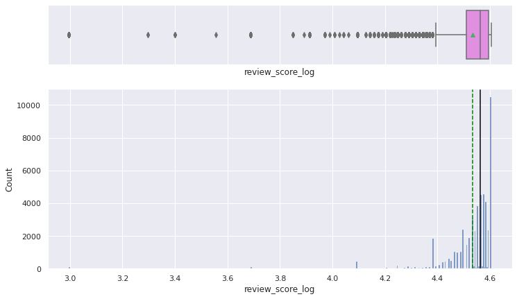

```python
#review_scores_rating
histogram_boxplot(AirBnBdf, "review_score_log")
```

Treating outliers of review_scores_rating data does not show any improvement. So let us keep the review_scores_rating field as it is.

## Treat 0s in the log_price column

```python
# Drop the records that have log price as 0
AirBnBdf.loc[(AirBnBdf.log_price <= 0)]
```

|  | room_type | accommodates | bathrooms | cancellation_policy | cleaning_fee | review_score_log | instant_bookable | review_scores_rating | bedrooms | beds | Price | log_price | ratings_bin |
| --- | --- | --- | --- | --- | --- | --- | --- | --- | --- | --- | --- | --- | --- |
| 11632 | Shared room | 1.0 | 1.0 | strict | True | 4.465908 | t | 87.0 | 1.0 | 1.0 | 1.0 | 0.0 | Excellent |

There is only one record with 0 log_price so we can delete this record, as it does not have a major impact on the dataset.

```python
AirBnBdf.drop(AirBnBdf.index[AirBnBdf['log_price'] == 0], inplace = True) # drop the row that has log price as 0
```

## Create different subsets of the AirBnBdf dataframe

```python
AirBnBdf.info()
```

```
<class 'pandas.core.frame.DataFrame'>
Int64Index: 50476 entries, 0 to 74110
Data columns (total 13 columns):
 #   Column                Non-Null Count  Dtype
---  ------                --------------  -----
 0   room_type             50476 non-null  category
 1   accommodates          50476 non-null  float64
 2   bathrooms             50476 non-null  float64
 3   cancellation_policy   50476 non-null  category
 4   cleaning_fee          50476 non-null  category
 5   review_score_log      50476 non-null  float64
 6   instant_bookable      50476 non-null  category
 7   review_scores_rating  50476 non-null  float64
 8   bedrooms              50476 non-null  float64
 9   beds                  50476 non-null  float64
 10  Price                 50476 non-null  float64
 11  log_price             50476 non-null  float64
 12  ratings_bin           50476 non-null  category
dtypes: category(5), float64(8)
memory usage: 3.7 MB
```

```python
df_withoutlog = AirBnBdf[['room_type','accommodates','bathrooms','cancellation_policy','cleaning_fee','instant_bookable','ratings_bin','bedrooms','beds','Price']]
```

```python
df_withlog = AirBnBdf[['room_type','accommodates','bathrooms','cancellation_policy','cleaning_fee','instant_bookable','review_score_log','bedrooms','beds','log_price']]
```

```python
df_luxury = df_withoutlog[(df_withoutlog.Price > 1500)]
df_luxury['log_price']  = 0
df_luxury['log_price'] = np.log(df_luxury.Price)
df_luxury = df_luxury.drop('Price', axis=1)
```

```python
# without the outliers for price
df_withoutoutliers = df_withlog[(df_withlog.log_price < 7)]
```

```python
#selective values for SFS
df_sfs = AirBnBdf[['room_type','accommodates','bathrooms','cancellation_policy','cleaning_fee','instant_bookable','bedrooms','beds','log_price','review_score_log']]
```

## Creating dummy variables

```python
df_WithDummies = pd.get_dummies(
    AirBnBdf,
    columns=AirBnBdf.select_dtypes(include=["object", "category"]).columns.tolist(),
    drop_first=True,
)

AirBnBdf.head()
```

|  | room_type | accommodates | bathrooms | cancellation_policy | cleaning_fee | review_score_log | instant_bookable | review_scores_rating | bedrooms | beds | Price | log_price | ratings_bin |
| --- | --- | --- | --- | --- | --- | --- | --- | --- | --- | --- | --- | --- | --- |
| 0 | Private room | 3.0 | 1.0 | strict | True | 4.605170 | f | 100.0 | 1.0 | 1.0 | 150.0 | 5.010635 | Excellent |
| 1 | Entire home/apt | 7.0 | 1.0 | strict | True | 4.532599 | t | 93.0 | 3.0 | 3.0 | 169.0 | 5.129899 | Excellent |
| 2 | Entire home/apt | 5.0 | 1.0 | moderate | True | 4.521789 | t | 92.0 | 1.0 | 3.0 | 145.0 | 4.976734 | Excellent |
| 3 | Entire home/apt | 4.0 | 1.0 | flexible | True | 4.574711 | f | 97.0 | 2.0 | 2.0 | 750.0 | 6.620073 | Excellent |
| 4 | Entire home/apt | 2.0 | 1.0 | moderate | True | 3.688879 | t | 40.0 | 1.0 | 1.0 | 115.0 | 4.744932 | Satisfactory |

```python
df_WithDummies.isnull().sum()
```

```
accommodates                    0
bathrooms                       0
review_score_log                0
review_scores_rating            0
bedrooms                        0
beds                            0
Price                           0
log_price                       0
room_type_Private room          0
room_type_Shared room           0
cancellation_policy_moderate    0
cancellation_policy_strict      0
cleaning_fee_True               0
instant_bookable_t              0
ratings_bin_Satisfactory        0
ratings_bin_Good                0
ratings_bin_Very Good           0
ratings_bin_Excellent           0
dtype: int64
```

From the df_WithDummies dataframe, we can drop the `review_score_log`,`review_score_rating`,`Price` columns as they are redundant

```python
df_WithDummies = df_WithDummies.drop(['review_score_log','review_scores_rating','Price'],axis=1)
```

```python
df_WithDummies.info()
```

```
<class 'pandas.core.frame.DataFrame'>
Int64Index: 50476 entries, 0 to 74110
Data columns (total 15 columns):
 #   Column                        Non-Null Count  Dtype
---  ------                        --------------  -----
 0   accommodates                  50476 non-null  float64
 1   bathrooms                     50476 non-null  float64
 2   bedrooms                      50476 non-null  float64
 3   beds                          50476 non-null  float64
 4   log_price                     50476 non-null  float64
 5   room_type_Private room        50476 non-null  uint8
 6   room_type_Shared room         50476 non-null  uint8
 7   cancellation_policy_moderate  50476 non-null  uint8
 8   cancellation_policy_strict    50476 non-null  uint8
 9   cleaning_fee_True             50476 non-null  uint8
 10  instant_bookable_t            50476 non-null  uint8
 11  ratings_bin_Satisfactory      50476 non-null  uint8
 12  ratings_bin_Good              50476 non-null  uint8
 13  ratings_bin_Very Good         50476 non-null  uint8
 14  ratings_bin_Excellent         50476 non-null  uint8
dtypes: float64(5), uint8(10)
memory usage: 2.8 MB
```

## Bivariate analysis

##### cleaning_fee vs log_price

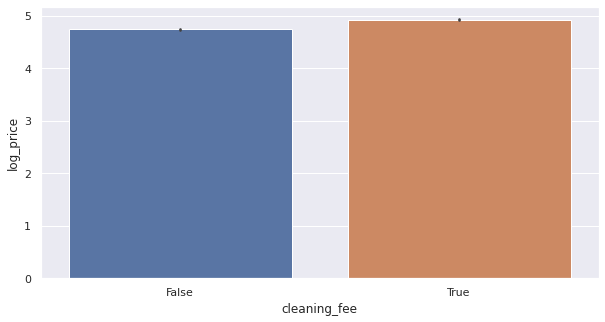

```python
plt.figure(figsize=(10, 5))
sns.barplot(x="cleaning_fee", y="log_price", data=AirBnBdf)
plt.show()
```

- Price is slightly higher when there is a cleaning fee.

##### cancellation_policy vs log_price

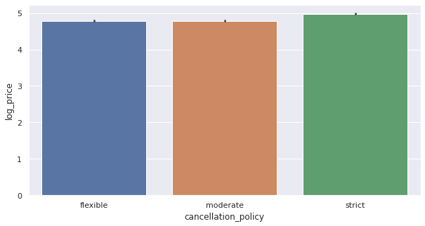

```python
plt.figure(figsize=(10, 5))
sns.barplot(x="cancellation_policy", y="log_price", data=AirBnBdf)
plt.show()
```

- Price is slightly higher when the cancellation policy is strict.

##### instant_bookable vs log_price

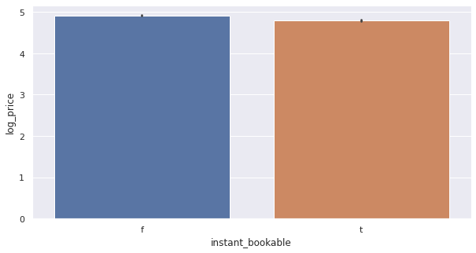

```python
plt.figure(figsize=(10, 5))
sns.barplot(x="instant_bookable", y="log_price", data=AirBnBdf)
plt.show()
```

- Price is slightly higher when the rental cannot be booked at an instant.

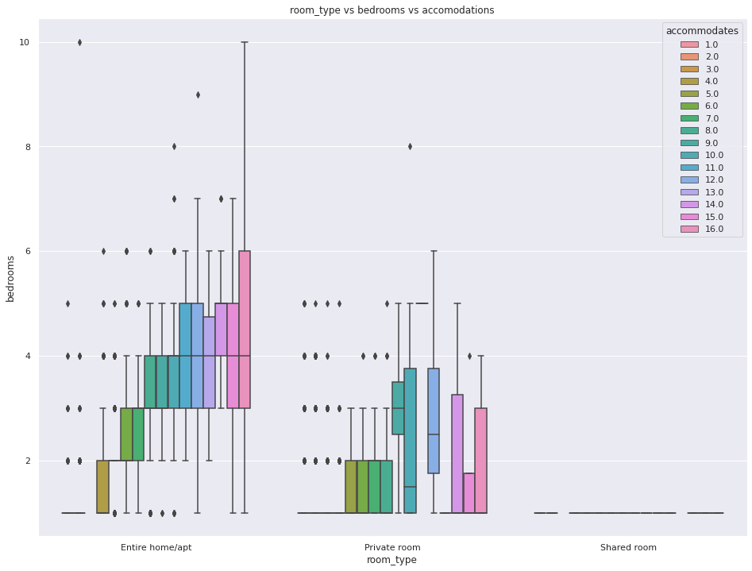

```python
plt.figure(figsize=(16,12))
sns.boxplot(data = AirBnBdf, x='room_type', y='bedrooms', hue ='accommodates')
plt.title('room_type vs bedrooms vs accomodations')
plt.show()
```

- There are several outliers in the bedroom numbers and the type of the accomodations
- Shared room did not have any impact as they have single room mostly.

```python
AirBnBdf.info()
```

```
<class 'pandas.core.frame.DataFrame'>
Int64Index: 50476 entries, 0 to 74110
Data columns (total 13 columns):
 #   Column                Non-Null Count  Dtype
---  ------                --------------  -----
 0   room_type             50476 non-null  category
 1   accommodates          50476 non-null  float64
 2   bathrooms             50476 non-null  float64
 3   cancellation_policy   50476 non-null  category
 4   cleaning_fee          50476 non-null  category
 5   review_score_log      50476 non-null  float64
 6   instant_bookable      50476 non-null  category
 7   review_scores_rating  50476 non-null  float64
 8   bedrooms              50476 non-null  float64
 9   beds                  50476 non-null  float64
 10  Price                 50476 non-null  float64
 11  log_price             50476 non-null  float64
 12  ratings_bin           50476 non-null  category
dtypes: category(5), float64(8)
memory usage: 6.2 MB
```

##### Heatmap of Corelation Matrix Without Log Transform

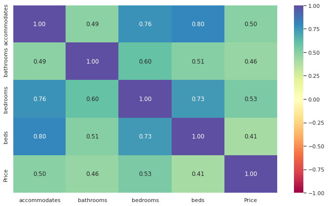

```python
plt.figure(figsize=(12, 7))
sns.heatmap(
    df_withoutlog.corr(), annot=True, vmin=-1, vmax=1, fmt=".2f", cmap="Spectral"
)
plt.show()
```

##### Heatmap of Corelation Matrix With Log Transform

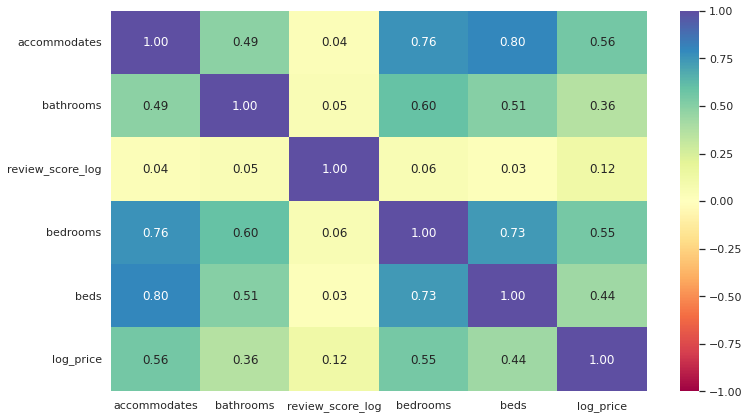

```python
plt.figure(figsize=(12, 7))
sns.heatmap(
    df_withlog.corr(), annot=True, vmin=-1, vmax=1, fmt=".2f", cmap="Spectral"
)
plt.show()
```

##### Heatmap of Corelation Matrix With Dummies

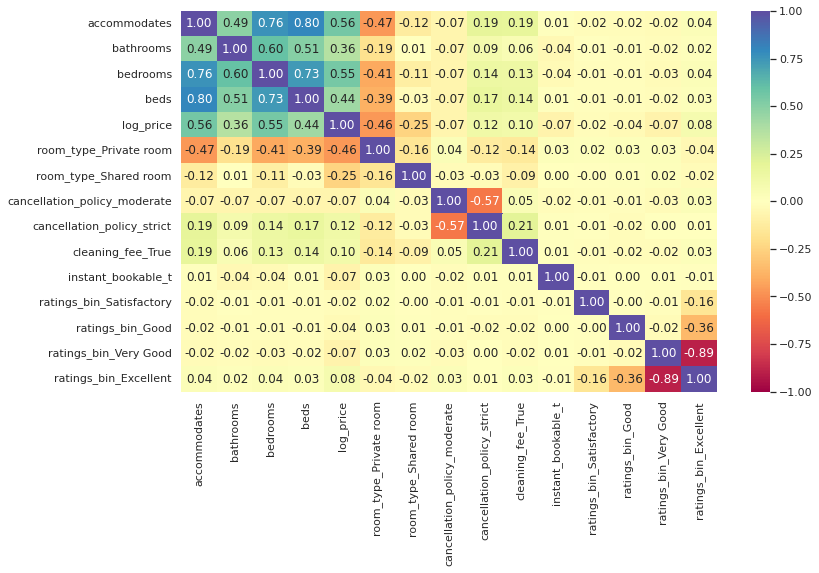

```python
plt.figure(figsize=(12, 7))
sns.heatmap(
    df_WithDummies.corr(), annot=True, vmin=-1, vmax=1, fmt=".2f", cmap="Spectral"
)
plt.show()
```

#### Summary of EDA

**Data Description:**

- The target variable (`log_price`) is of *float* type.
- *room_type, accommodates, bathrooms, cleaning_fee, cancellation_policy,instant_bookable,bedrooms,beds* seem to have finite set of values, probably they can be considered as categorical values. Let us find out the disctinct values in these columns and decide based on that.
- *review_scores_rating* seem to have a range of values, let us find out the min and max range for this column.
- *log_price* column might need some processing, let us do some processing and see what the actual price looks like.
- The column data types seem to be aligned with the values in the columns, categorical values have been converted to category data type and dummy values have been created.

**Data Cleaning:**

- *id* column is just an index column, as this does not have any value to our model, so we can drop this column.
- Except log_price and instant_bookable columns the rest of the columns have missing values.
- The review_scores_rating column has the most number of missing values.
- accomodates - group by median for missing values
- `room_type` replace missing values of `room type` as Entire home/apt if the rental property can accomodate 4 or more people
- replace missing values of `room type` as Private room if the rental property can accomodate between 2 to 3 persons
- if the room accomodates only one person then it is a Private room

`cleaning_fee`

- since, majority of rental properties have cleaning fee
- we can assign the majority value for the missing values

`cancellation_policy`

- majority of properties have strict cancellation
- we can assign the majority value for the missing values

`bedrooms`

- single bedroom rentals can accomodate upto 4 people.
- Rentals having 2 to 3 bedrooms can accomodate upto 9 people
- For accomodating 10 people or more the rentals have 4 or more bedrooms.
- Taking this into consideration, we can set the missing bedroom counts accordingly.

`bathrooms`

- From the group by median data 2 bathrooms for accomodations between 6 and 11. For accomodations more than 11, consider 3 bathrooms.

`beds`

- Single bed can accomodate upto 3 people
- 2 beds for 4 people
- Between 5 and 6 people 3 beds are needed
- Between 7 and 8 people 4 beds are needed,
- 9 and 10 people = 5 beds
- 11 and 12 people = 6 beds
- To accomodate 13 and above 7 beds are required

`review_scores`

- It looks like the average rating for all the room types is above 90. Which means most of the accomodations have an excellent score.
- This data seems to have lot of outliers.
- This column has been binned for better analysis.

`log_price`

- Do inverse log on Price column to find the actual price.

**Duplicates:**

There were 23633 duplicate rows, they have been dropped.

**Observations**

# 6.Linear Regression - Model building

## Model performance check

- We will be using metric functions defined in sklearn for RMSE, MAE, and $R^2$.
- We will define functions to calculate adjusted $R^2$ and MAPE.
  - The mean absolute percentage error (MAPE) measures the accuracy of predictions as a percentage, and can be calculated as the average absolute percent error for each predicted value minus actual values divided by actual values. It works best if there are no extreme values in the data and none of the actual values are 0.
- We will create a function that will print out all the above metrics in one go.

### Function to compute adjusted R-squared

```python
# function to compute adjusted R-squared
def adj_r2_score(predictors, targets, predictions):
    r2 = r2_score(targets, predictions)
    n = predictors.shape[0]
    k = predictors.shape[1]
    return 1 - ((1 - r2) * (n - 1) / (n - k - 1))


# function to compute MAPE
def mape_score(targets, predictions):
    return np.mean(np.abs(targets - predictions) / targets) * 100


# function to compute different metrics to check performance of a regression model
def model_performance_regression(model, predictors, target):
    """
    Function to compute different metrics to check regression model performance

    model: regressor
    predictors: independent variables
    target: dependent variable
    """

    # predicting using the independent variables
    pred = model.predict(predictors)

    r2 = r2_score(target, pred)  # to compute R-squared
    adjr2 = adj_r2_score(predictors, target, pred)  # to compute adjusted R-squared
    rmse = np.sqrt(mean_squared_error(target, pred))  # to compute RMSE
    mae = mean_absolute_error(target, pred)  # to compute MAE
    mape = mape_score(target, pred)  # to compute MAPE

    # creating a dataframe of metrics
    df_perf = pd.DataFrame(
        {
            "RMSE": rmse,
            "MAE": mae,
            "R-squared": r2,
            "Adj. R-squared": adjr2,
            "MAPE": mape,
        },
        index=[0],
    )

    return df_perf
```

## Using the data with log

### Prepare the data

```python
df_withlog.info()
```

```
<class 'pandas.core.frame.DataFrame'>
Int64Index: 50476 entries, 0 to 74110
Data columns (total 10 columns):
 #   Column               Non-Null Count  Dtype
---  ------               --------------  -----
 0   room_type            50476 non-null  category
 1   accommodates         50476 non-null  float64
 2   bathrooms            50476 non-null  float64
 3   cancellation_policy  50476 non-null  category
 4   cleaning_fee         50476 non-null  category
 5   instant_bookable     50476 non-null  category
 6   review_score_log     50476 non-null  float64
 7   bedrooms             50476 non-null  float64
 8   beds                 50476 non-null  float64
 9   log_price            50476 non-null  float64
dtypes: category(4), float64(6)
memory usage: 5.4 MB
```

```python
df_withlog.drop('review_score_log',axis=1) # drop the review score column as it has a negative correlation with price
```

|  | room_type | accommodates | bathrooms | cancellation_policy | cleaning_fee | instant_bookable | bedrooms | beds | log_price |
| --- | --- | --- | --- | --- | --- | --- | --- | --- | --- |
| 0 | Private room | 3.0 | 1.0 | strict | True | f | 1.0 | 1.0 | 5.010635 |
| 1 | Entire home/apt | 7.0 | 1.0 | strict | True | t | 3.0 | 3.0 | 5.129899 |
| 2 | Entire home/apt | 5.0 | 1.0 | moderate | True | t | 1.0 | 3.0 | 4.976734 |
| 3 | Entire home/apt | 4.0 | 1.0 | flexible | True | f | 2.0 | 2.0 | 6.620073 |
| 4 | Entire home/apt | 2.0 | 1.0 | moderate | True | t | 1.0 | 1.0 | 4.744932 |
| ... | ... | ... | ... | ... | ... | ... | ... | ... | ... |
| 74104 | Entire home/apt | 2.0 | 1.0 | strict | True | f | 1.0 | 1.0 | 4.356709 |
| 74107 | Entire home/apt | 4.0 | 2.0 | moderate | True | f | 2.0 | 4.0 | 5.043425 |
| 74108 | Entire home/apt | 5.0 | 1.0 | moderate | True | t | 2.0 | 2.0 | 5.220356 |
| 74109 | Entire home/apt | 2.0 | 1.0 | strict | True | t | 1.0 | 2.0 | 5.273000 |
| 74110 | Entire home/apt | 4.0 | 1.0 | moderate | False | f | 1.0 | 2.0 | 4.852030 |

50476 rows × 9 columns

```python
df_withlog = pd.get_dummies(
    df_withlog,
    columns=df_withlog.select_dtypes(include=["object", "category"]).columns.tolist(),
    drop_first=True,
)

df_withlog.head()
```

|  | accommodates | bathrooms | review_score_log | bedrooms | beds | log_price | room_type_Private room | room_type_Shared room | cancellation_policy_moderate | cancellation_policy_strict | cleaning_fee_True | instant_bookable_t |
| --- | --- | --- | --- | --- | --- | --- | --- | --- | --- | --- | --- | --- |
| 0 | 3.0 | 1.0 | 4.605170 | 1.0 | 1.0 | 5.010635 | 1 | 0 | 0 | 1 | 1 | 0 |
| 1 | 7.0 | 1.0 | 4.532599 | 3.0 | 3.0 | 5.129899 | 0 | 0 | 0 | 1 | 1 | 1 |
| 2 | 5.0 | 1.0 | 4.521789 | 1.0 | 3.0 | 4.976734 | 0 | 0 | 1 | 0 | 1 | 1 |
| 3 | 4.0 | 1.0 | 4.574711 | 2.0 | 2.0 | 6.620073 | 0 | 0 | 0 | 0 | 1 | 0 |
| 4 | 2.0 | 1.0 | 3.688879 | 1.0 | 1.0 | 4.744932 | 0 | 0 | 1 | 0 | 1 | 1 |

### Define dependent variable

```python
X = df_withlog.drop(["log_price"], axis=1)
y = df_withlog["log_price"]
```